# 第8回 クラスタリング：k-meansと階層的クラスタリング

答えの無い星を、似たものどうしでまとめる

# 導入

## 第7回は買い物、今日は星

① 今日のデータ●○

- 第7回は、ネットショップの訪問から、購入を見分けた
- 第6・7回のデータには、当てたい答えの列があった
- 今日のデータには、答えの列が無い

## 宇宙の地図を作る衛星

① 今日のデータ●●

- ヨーロッパ宇宙機関（ESA）の衛星Gaiaは、空の星の位置・明るさ・色を測り続けている
- 測った値は、誰でも使える公開データとして配られている
- 今日は、太陽のまわりの星を、そこから取ってきた

## 星には種類がある

② 場面●○○

- 夜空の星は、どれも同じに見える
- でも、色と本当の明るさを並べると、星の種類が分かれて見える
- 天文学者は、その図を見て、星の種類を見分けてきた

## 決めたいこと

② 場面●●○

- 答えの列（この星は何の種類か）が無いまま、星を似たものどうしでまとめたい
- まとめた群が、天文学者の見分ける種類と合うか

## クラスタリング

② 場面●●●

- 似た行どうしをまとめて、いくつかの群（クラスター）に分けること
- 答えの列を使わない。データの値の近さだけで分ける
- 今日は、いちばん基本の方法k-meansと、階層的クラスタリングを使う

## 手元のデータ

③ 手元のデータ●○

- Gaia第3版（DR3）から、太陽の近くの星を、測りの質の条件で絞って取った
- 1行が星1つ。列は、視差・見かけの等級・色の3本
- 27,860個。答えの列は無い

## データをのぞく

③ 手元のデータ●●

|  | source_id | parallax | phot_g_mean_mag | bp_rp |
| --- | --- | --- | --- | --- |
| 0 | 123424475948672 | 22.499347 | 14.900652 | 3.198625 |
| 1 | 452212812313984 | 24.114540 | 13.457018 | 2.572324 |
| 2 | 630505494719360 | 67.933502 | 8.457596 | 1.727691 |

- `source_id`は星の番号。残りの3本の意味は、1節で読む

## 最後に出す答え

④ 今日の問い●○

- 星を似たものどうしでまとめると、星の種類が分かれるか
- 分かれないなら、なぜか。何個に、どう分ければよいか

## 今日の問い

④ 今日の問い●●

答えの列が無い星を、似たものどうしでまとめると、星の種類が分かれるか。何個に、どう分ければよいか？

## もう1つのねらい：while

⑤ もう1つのねらい●

- 止まる条件を書いて、`while`で「動かなくなるまで」くり返す手順を読めるようになる
- k-meansの中身を`while`で書いたものを、1行ずつ読む
- お手本ごとに、コードを1行ずつ読み、変数の中身を見る

# 今日の一周

## 結果だけで一度通す

⑥ 今日の一周●○○○○○○○

- まず、今日の解析を、結果だけで一度通して見る
- コードはあとで。どんな結論になるかを先に知っておく

## 一周①：色と明るさを並べる

⑥ 今日の一周●●○○○○○○

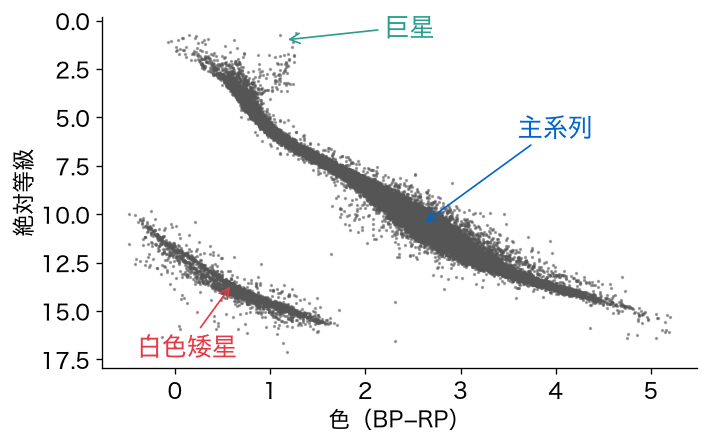

- 長い帯（主系列）と、左下の小さな帯（白色矮星）。目で見ると2種類

## 一周②：2つに分けると

⑥ 今日の一周●●●○○○○○

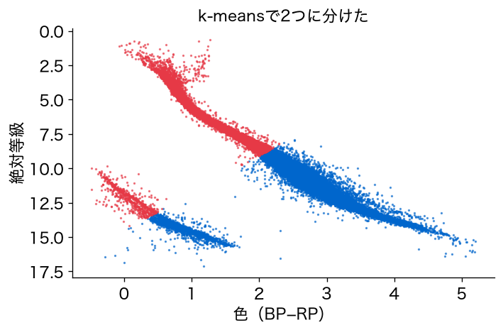

- えっ、白色矮星が真っ二つ。主系列も、途中で輪切りになった

## 一周③：していることは、くり返し

⑥ 今日の一周●●●●○○○○

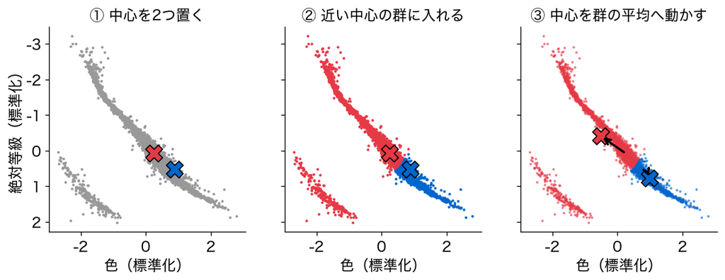

- 近い中心の群に入れ、中心を群の平均へ動かす。動かなくなるまでくり返す

## 一周④：輪切りのほうが小さい

⑥ 今日の一周●●●●●○○○

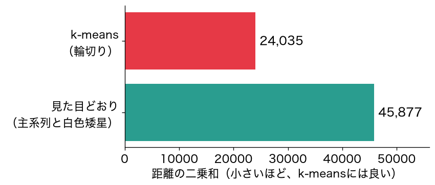

- k-meansは、中心までの距離の二乗和を小さくする。見た目どおりの分け方は、2倍近く大きい

## 一周⑤：何個に分ける？

⑥ 今日の一周●●●●●●○○

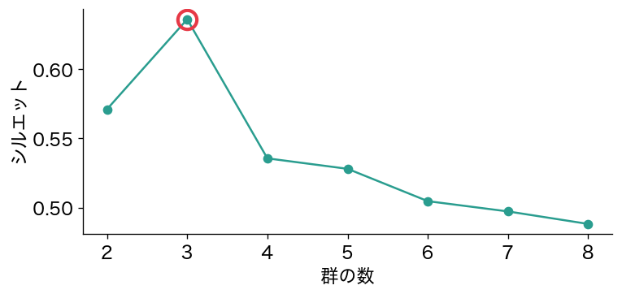

- シルエットという指針では、3つがいちばん良い。別の指針Gapは、8まで伸び続ける

## 一周⑥：つなぎ方を替えると

⑥ 今日の一周●●●●●●●○

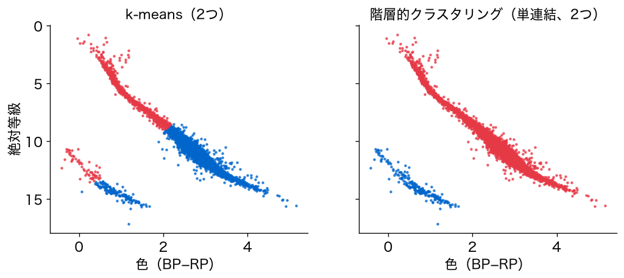

- 近い星どうしを鎖のようにつなぐ分け方なら、2つの帯がそのまま分かれる

## 一周は4つの段

⑥ 今日の一周●●●●●●●●

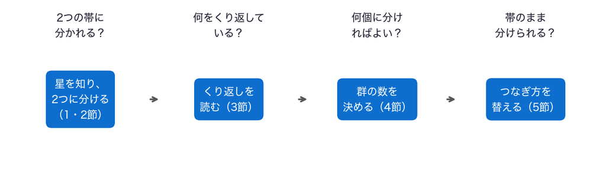

- このあと、4つの段の中身を、1つずつ開けていく

## 問いとやること①②

⑦ 問いとやること●○

- 知って分ける：2つの帯に分かれる？ → 視差から本当の明るさを出してHR図を描き、標準化してk-meansで2つに分ける（1・2節）
- くり返しを読む：何をくり返している？ → `while`で書いたk-meansを1行ずつ読み、二乗和と、止まる所を比べる（3節）

## 問いとやること③④

⑦ 問いとやること●●

- 群の数を決める：何個に分ければよい？ → 群の数を替えて、二乗和・Gap・シルエットを並べる（4節）
- つなぎ方を替える：帯のまま分けられる？ → 近い星からつないでいく階層的クラスタリングで分け、樹形図を読む（5節）

## 今日の進め方

⑧ 今日の進め方●

- 段ごとに、スライドで聞く → ノートで実行して答える
- 段の終わりの「ノートへ」で、予想を書き、1か所を替えて実行し、予想と比べる
- 予想は外れてかまわない

# 0. 準備

## まずは道具を呼び出す

- 0節は、道具を呼び出すだけ。ノートで1節と続けて実行する

# 1. 星の何を比べる？

## 段1：知って分ける

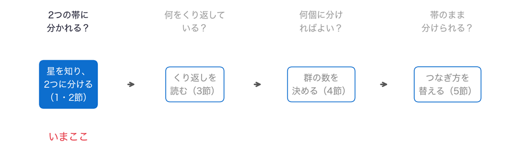

- 問い：星を2つに分けると、主系列と白色矮星に分かれるか
- まず、表を読み込み、3本の列の意味を読む（1節）。そのあと、k-meansで分ける（2節）

## お手本：表を読み込む

1節 ① 読み込む●○

```python
# データはこのリポジトリから読み込む
DATA_DIR = ('https://raw.githubusercontent.com/k0heiun0/'
            'applied_exercise_preview/main/shared/data')
raw = pd.read_csv(f'{DATA_DIR}/gaia_nearby.csv')
print(len(raw), '個')
raw.head(3)
```

```
27860 個
```

## 1行ずつ：表を読み込む

1節 ① 読み込む●●

```python
# データはこのリポジトリから読み込む
DATA_DIR = ('https://raw.githubusercontent.com/k0heiun0/'
            'applied_exercise_preview/main/shared/data')
raw = pd.read_csv(f'{DATA_DIR}/gaia_nearby.csv')
print(len(raw), '個')
raw.head(3)
```

- `DATA_DIR`の行：データの置き場所を`DATA_DIR`にしまう
- `pd.read_csv`の行：置き場所の`gaia_nearby.csv`を読み、表`raw`にしまう
- `print`と`head`の行：星の数を表示し、先頭3行を見る

## 3本の列

1節 ② 列の意味●○

| 列 | 意味 |
| --- | --- |
| `parallax` | 視差（ミリ秒角）。大きいほど近い |
| `phot_g_mean_mag` | 見かけの等級。地球から見た明るさ。小さいほど明るい |
| `bp_rp` | 色。青で測った等級と赤で測った等級の差。小さいほど青く、熱い |

## 視差：近い星ほど、大きく揺れる

1節 ② 列の意味●●

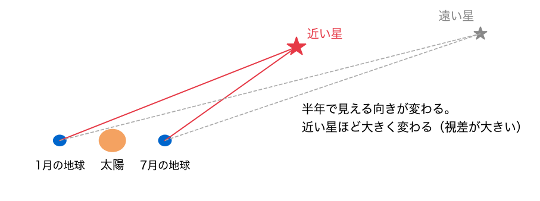

- 視差から、星までの距離が分かる

## お手本：列の名前を日本語に

1節 ③ 列の名前●○

```python
names = {'parallax': '視差', 'phot_g_mean_mag': '見かけの等級',
         'bp_rp': '色'}
df = raw.rename(columns=names)
df.head(3)
```

|  | source_id | 視差 | 見かけの等級 | 色 |
| --- | --- | --- | --- | --- |
| 0 | 123424475948672 | 22.499347 | 14.900652 | 3.198625 |
| 1 | 452212812313984 | 24.114540 | 13.457018 | 2.572324 |
| 2 | 630505494719360 | 67.933502 | 8.457596 | 1.727691 |

## 1行ずつ：列の名前を日本語に

1節 ③ 列の名前●●

```python
names = {'parallax': '視差', 'phot_g_mean_mag': '見かけの等級',
         'bp_rp': '色'}
df = raw.rename(columns=names)
df.head(3)
```

- 1・2行目：元の名前を鍵に、日本語の名前を値にした辞書を作る（第5回）
- 3行目：辞書のとおりに列の名前を替え、表`df`にしまう
- 4行目：先頭3行を見る

## 見かけの明るさと、本当の明るさ

1節 ④ 本当の明るさ●○○○○

- 同じ明るさの星でも、遠くにあれば暗く見える
- 星そのものの明るさを比べるには、距離をそろえる必要がある
- 星を10パーセクの距離に並べたときの等級を、絶対等級という

## 式：距離と絶対等級

1節 ④ 本当の明るさ●●○○○

視差 $\varpi$（ミリ秒角）から、距離 $d$（パーセク）を出す。

$$d = \frac{1000}{\varpi}$$

見かけの等級 $m$ と距離 $d$ から、絶対等級 $M$ を出す。

$$M = m - 5 \log_{10} \frac{d}{10}$$

## お手本：距離と絶対等級

1節 ④ 本当の明るさ●●●○○

```python
df['距離'] = 1000 / df['視差']
df['絶対等級'] = df['見かけの等級'] - 5 * np.log10(df['距離'] / 10)
print(df['距離'].round(1).max())
df[['視差', '距離', '見かけの等級', '絶対等級']].head(3).round(2)
```

```
50.0
```

|  | 視差 | 距離 | 見かけの等級 | 絶対等級 |
| --- | --- | --- | --- | --- |
| 0 | 22.50 | 44.45 | 14.90 | 11.66 |
| 1 | 24.11 | 41.47 | 13.46 | 10.37 |
| 2 | 67.93 | 14.72 | 8.46 | 7.62 |

## 1行ずつ：距離と絶対等級

1節 ④ 本当の明るさ●●●●○

```python
df['距離'] = 1000 / df['視差']
df['絶対等級'] = df['見かけの等級'] - 5 * np.log10(df['距離'] / 10)
print(df['距離'].round(1).max())
df[['視差', '距離', '見かけの等級', '絶対等級']].head(3).round(2)
```

- 1行目：1000を視差で割って、距離の列を作る
- 2行目：式のとおりに、絶対等級の列を作る（`np.log10`は常用対数）
- 3・4行目：いちばん遠い星の距離と、先頭3行を見る

## 太陽のまわりの星だけ

1節 ④ 本当の明るさ●●●●●

- いちばん遠い星でも、50パーセク。太陽のまわりの、ごく近い星だけを取った
- 近い星ほど、暗い星まで測れる。遠くの暗い星は、測りの質の条件で落ちている

## お手本：HR図を描く

1節 ⑤ HR図●○○○

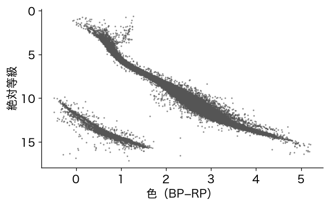

```python
plt.figure(figsize=(7, 5))
plt.scatter(df['色'], df['絶対等級'], s=1)
plt.gca().invert_yaxis()
plt.xlabel('色（BP−RP）')
plt.ylabel('絶対等級')
plt.show()
```

## 1行ずつ：HR図を描く

1節 ⑤ HR図●●○○

```python
plt.figure(figsize=(7, 5))
plt.scatter(df['色'], df['絶対等級'], s=1)
plt.gca().invert_yaxis()
plt.xlabel('色（BP−RP）')
plt.ylabel('絶対等級')
plt.show()
```

- 2行目：横に色、縦に絶対等級をとり、星を1つずつ点で打つ（`s=1`は小さな点）
- 3行目：縦軸を上下逆にする。等級は小さいほど明るいので、明るい星を上にする

## HR図を読む

1節 ⑤ HR図●●●○

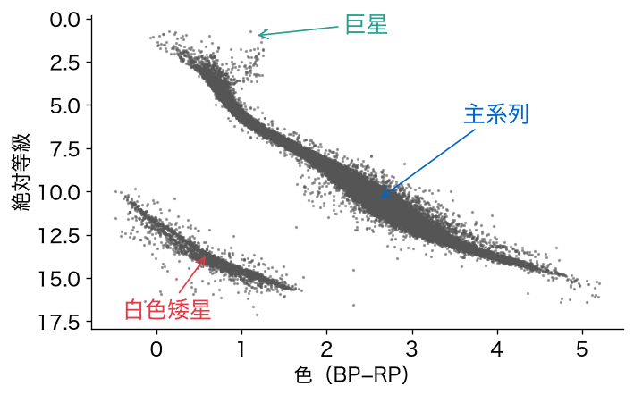

- この図を、ヘルツシュプルング・ラッセル図（HR図）という

## 主系列と白色矮星

1節 ⑤ HR図●●●●

- 主系列：太陽の仲間。中心で水素を燃やして光る。青く熱い星ほど明るい
- 白色矮星：燃え尽きた星の芯。小さいので、熱く青くても暗い
- 巨星：年老いてふくらんだ星。赤いのに明るい。この近さには少ない

## お手本：白色矮星を数える

1節 ⑥ 目安の線●○○

```python
df['白色矮星'] = (df['絶対等級'] > 4 * df['色'] + 8.5).astype(int)
print(df['白色矮星'].sum(), '個')
```

```
2027 個
```

- 図を見て、2つの帯のあいだに直線を引いた。線より下（暗い側）を白色矮星とする

## 1行ずつ：目安の線

1節 ⑥ 目安の線●●○

```python
df['白色矮星'] = (df['絶対等級'] > 4 * df['色'] + 8.5).astype(int)
print(df['白色矮星'].sum(), '個')
```

- 1行目：絶対等級が「4×色＋8.5」より大きい（暗い）星を1、それ以外を0にした列を作る
- 2行目：1の数、つまり白色矮星の数を表示する

## 目安の線は、答え合わせだけに使う

1節 ⑥ 目安の線●●●

- この列は、私が図を見て決めた答えのようなもの
- k-meansには渡さない。分けたあとの答え合わせだけに使う
- k-meansが使うのは、色と絶対等級の2本だけ

## 結果を見る前に、予想を書く

1節 ⑦ 予想●

- 星を2つに分けたら、主系列と白色矮星に分かれるだろうか
- 目で見ると、2つの帯ははっきり離れている
- 予想を書いてから、2節へ進む

# 2. 2つに分けると？

## 目で見た2種類を、値で分ける

2節 ① 近さ●○

- 視差から距離と絶対等級を出し、色と並べてHR図を描いた
- 目で見ると、長い帯の主系列と、左下の白色矮星（2,027個）の2種類
- ここから、値の近さだけで、星を2つに分ける

## 近さは、距離で測る

2節 ① 近さ●●

- 2つの星の近さを、図の上の距離で測る
- 色と絶対等級の差を、それぞれ2乗して足す（距離の2乗）
- 単位がばらばらだと、幅の大きい列の差ばかりが効いてしまう。絶対等級のほうが、色よりずっと広く散らばる

## お手本：標準化する

2節 ② 標準化●○

```python
from sklearn.preprocessing import StandardScaler
X = StandardScaler().fit_transform(df[['色', '絶対等級']])
print(X[:3].round(2))
```

```
[[ 0.89  0.54]
 [ 0.25  0.08]
 [-0.6  -0.88]]
```

## 1行ずつ：標準化する

2節 ② 標準化●●

```python
from sklearn.preprocessing import StandardScaler
X = StandardScaler().fit_transform(df[['色', '絶対等級']])
print(X[:3].round(2))
```

- 1行目：標準化の道具を呼び出す（第7回のおさらい）
- 2行目：2本の列を、平均0・標準偏差1にそろえ、配列`X`にしまう
- 3行目：先頭3つの星の、標準化した値を見る。1列目が色、2列目が絶対等級

## k-means

2節 ③ k-means●

- 群の数 $k$ を先に決める。今日は、まず $k=2$
- 中心を $k$ 個置き、星をいちばん近い中心の群に入れる
- 中心の置き方は、道具`KMeans`が決める。中身は3節で読む

## お手本：2つに分ける

2節 ④ 2つに分ける●○○○

```python
from sklearn.cluster import KMeans
km = KMeans(2, n_init=10, random_state=0)
km.fit(X)
df['群'] = km.labels_
print(df['群'].value_counts())
```

```
群
0    19806
1     8054
Name: count, dtype: int64
```

## 1行ずつ：2つに分ける①

2節 ④ 2つに分ける●●○○

```python
from sklearn.cluster import KMeans
km = KMeans(2, n_init=10, random_state=0)
km.fit(X)
df['群'] = km.labels_
print(df['群'].value_counts())
```

- 1行目：k-meansの道具`KMeans`を呼び出す
- 2行目：群の数2で準備する。`n_init=10`は出発点を10通り試す設定、`random_state`は乱数のシード
- 3行目：`X`に当てはめて、2つに分ける

## 1行ずつ：2つに分ける②

2節 ④ 2つに分ける●●●○

```python
from sklearn.cluster import KMeans
km = KMeans(2, n_init=10, random_state=0)
km.fit(X)
df['群'] = km.labels_
print(df['群'].value_counts())
```

- 4行目：星ごとの群の番号（0か1）を`km.labels_`から取り、列「群」にする
- 5行目：群ごとの星の数を数える

## 中身を見る：群の番号

2節 ④ 2つに分ける●●●●

```python
df[['色', '絶対等級', '群']].head(3).round(2)
```

|  | 色 | 絶対等級 | 群 |
| --- | --- | --- | --- |
| 0 | 3.20 | 11.66 | 0 |
| 1 | 2.57 | 10.37 | 0 |
| 2 | 1.73 | 7.62 | 1 |

- 星1つに、群の番号が1つ付いた。番号の0と1は、名前にすぎない

## お手本：群で塗る

2節 ⑤ 群で塗る●○

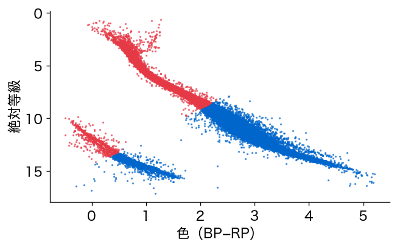

```python
plt.figure(figsize=(7, 5))
plt.scatter(df['色'], df['絶対等級'], s=1, c=df['群'],
            cmap='coolwarm')
plt.gca().invert_yaxis()
plt.xlabel('色（BP−RP）')
plt.ylabel('絶対等級')
plt.show()
```

## 1行ずつ：群で塗る

2節 ⑤ 群で塗る●●

```python
plt.figure(figsize=(7, 5))
plt.scatter(df['色'], df['絶対等級'], s=1, c=df['群'],
            cmap='coolwarm')
plt.gca().invert_yaxis()
plt.xlabel('色（BP−RP）')
plt.ylabel('絶対等級')
plt.show()
```

- 2・3行目：1節のHR図と同じ点を打ち、`c=df['群']`で、群の番号ごとに色を変える（`cmap`は色の組）
- ほかの行は、1節のHR図と同じ

## えっ、白色矮星が真っ二つ

2節 ⑥ えっ●

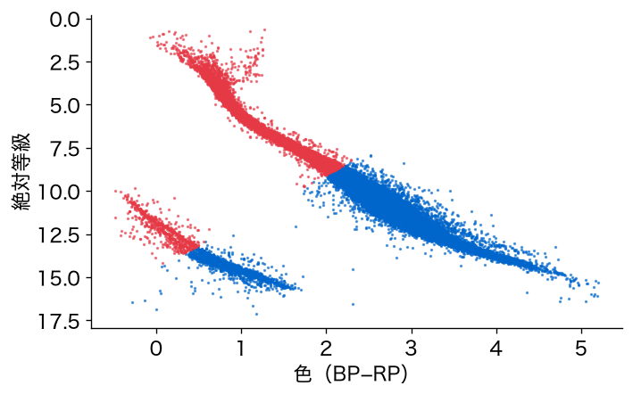

- 白色矮星の帯が、途中で切られた。主系列も、真ん中で切られた

## お手本：目安の線と比べる

2節 ⑦ 目安と比べる●○○○

```python
pd.crosstab(df['白色矮星'], df['群'])
```

| 群 白色矮星 | 0 | 1 |
| --- | --- | --- |
| 0 | 18384 | 7449 |
| 1 | 1422 | 605 |

- 行が目安の線（1が白色矮星）、列がk-meansの群。組ごとに星を数えた

## 1行ずつ：目安の線と比べる

2節 ⑦ 目安と比べる●●○○

```python
pd.crosstab(df['白色矮星'], df['群'])
```

- 1行目：目安の線の0・1と、群の0・1の組み合わせごとに、星の数を数える（`pd.crosstab`、第7回）
- 白色矮星2,027個のうち、1,422個が群0、605個が群1に入った

## 種類では、分かれなかった

2節 ⑦ 目安と比べる●●●○

- 白色矮星は、2つの群に割れた
- どちらの群にも、主系列と白色矮星がまざっている
- 目で見てはっきり離れた2つの帯を、k-meansは2つに分けなかった

## 重要：群の番号に意味はない

2節 ⑦ 目安と比べる●●●●

k-meansの群の番号は、名前にすぎない。番号が何の群かは、分けたあとに中身を見て読む。

## TODO①：群の数を替える

2節 ⑧ 群の数を替える●○

```python
# TODO: 2 を 3 に替えて実行する
km_x = KMeans(2, n_init=10, random_state=0)
km_x.fit(X)
pd.crosstab(df['白色矮星'], km_x.labels_)
```

- 予想：3つに分けると、白色矮星は1つの群にまとまるか

## ここまでで分かったこと

2節 ⑧ 群の数を替える●●

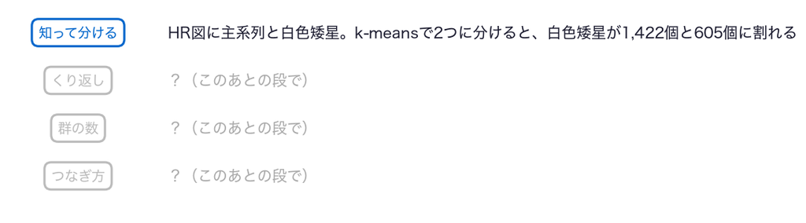

- まだ分からないのは、k-meansが中で何をしていて、なぜ輪切りにしたか

## ノートへ：0〜2節

2節 ⑨ ノートへ●

- 0〜2節のセルを上から実行し、スライドと同じ数が出るか確かめる
- 予想を書く：2つに分けたら、主系列と白色矮星に分かれるか
- TODO①：予想を書く → `2`を`3`に替えて実行 → 予想と比べる

動画の人は、ここで一時停止。

## 答え合わせ：TODO①

2節 10 答え合わせ●

```
col_0      0     1     2
白色矮星
0      18446     4  7383
1          0  2027     0
```

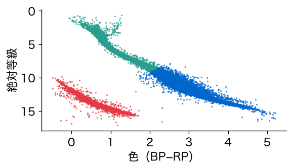

- 3つにすると、白色矮星は1つの群にまとまる。かわりに、主系列が2つに切られた

# 3. 何をくり返している？

## 段2：くり返しを読む

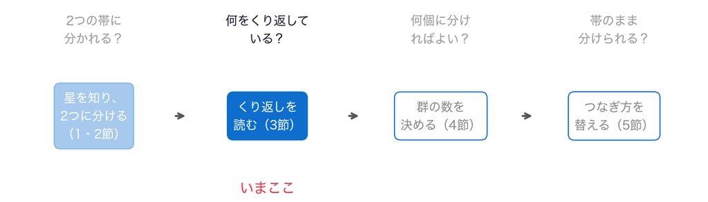

- 問い：k-meansは何をくり返していて、なぜ輪切りにしたのか

## 前の段から

- k-meansで2つに分けると、白色矮星が2つの群に割れた
- 3つに分けると白色矮星はまとまるが、主系列が切られる
- ここから、`KMeans`の中で何をしているかを読む

## k-meansの手順

3節 ① 手順●○○

- ① 中心を2つ置く（出発点）
- ② 星を、いちばん近い中心の群に入れる（割り当て）
- ③ 中心を、群の星の平均へ動かす（更新）。②と③を、中心が動かなくなるまでくり返す

## 手順を図で

3節 ① 手順●●○

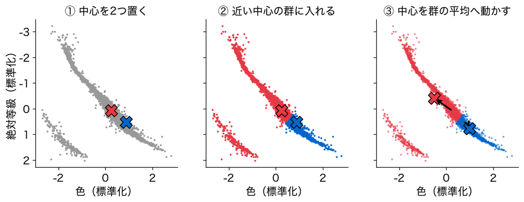

- 出発点は、表の0番目と1番目の星。③で、中心が群の平均へ動いた

## 式：割り当てと更新

3節 ① 手順●●●

星 $i$ の値を $x_i$、群 $j$ の中心を $\mu_j$ とする。

割り当て：$c_i = \arg\min_j \|x_i - \mu_j\|^2$（いちばん近い中心の番号）

更新：$\mu_j = \dfrac{1}{n_j} \sum_{c_i = j} x_i$（群 $j$ の $n_j$ 個の星の平均）

## 何回くり返せばよい？

3節 ② while●○○○

- 中心が動かなくなるまで。それが何回目かは、やってみるまで分からない
- `for`は、回数を先に決めてくり返す（`range(3)`なら3回）
- 回数が先に決まらないくり返しには、`while`を使う

## while：最小の例

3節 ② while●●○○

```python
x = 1
while x < 100:
    x = x * 2
print(x)
```

```
128
```

## 1行ずつ：while

3節 ② while●●●○

```python
x = 1
while x < 100:
    x = x * 2
print(x)
```

- 1行目：`x`を1にする
- 2行目：「`x`が100より小さいあいだ」、字下げした行をくり返す
- 3行目：`x`を2倍にする。4行目：くり返しが終わったら、`x`を表示する

## 中身を見る：xの動き

3節 ② while●●●●

```python
x = 1
while x < 100:
    x = x * 2
    print(x)
```

```
2  4  8  16  32  64  128
```

- 128になったところで、条件「100より小さい」を満たさなくなり、止まる

## お手本：近い中心の群に入れる

3節 ③ 割り当て●○

```python
def assign(X, C):
    d0 = ((X - C[0]) ** 2).sum(axis=1)
    d1 = ((X - C[1]) ** 2).sum(axis=1)
    return (d1 < d0).astype(int)
```

- 割り当て（手順②）を、関数`assign`にする。入力は星`X`と中心`C`、出力は群の番号

## 1行ずつ：近い中心の群に入れる

3節 ③ 割り当て●●

```python
def assign(X, C):
    d0 = ((X - C[0]) ** 2).sum(axis=1)
    d1 = ((X - C[1]) ** 2).sum(axis=1)
    return (d1 < d0).astype(int)
```

- 2行目：星ごとに、中心0までの距離の2乗を出す（色と絶対等級の差を2乗して、横に足す）
- 3行目：同じく、中心1までの距離の2乗を出す
- 4行目：中心1のほうが近ければ1、そうでなければ0を返す

## お手本：中心を平均へ動かす

3節 ④ 更新●○

```python
def update(X, lab):
    c0 = X[lab == 0].mean(axis=0)
    c1 = X[lab == 1].mean(axis=0)
    return np.array([c0, c1])
```

- 更新（手順③）を、関数`update`にする。入力は星`X`と群の番号`lab`、出力は新しい中心

## 1行ずつ：中心を平均へ動かす

3節 ④ 更新●●

```python
def update(X, lab):
    c0 = X[lab == 0].mean(axis=0)
    c1 = X[lab == 1].mean(axis=0)
    return np.array([c0, c1])
```

- 2行目：群0の星だけを取り出し、列ごとの平均（色の平均、絶対等級の平均）を出す
- 3行目：群1も同じ
- 4行目：2つの中心を、1つの配列にまとめて返す

## お手本：動かなくなるまでくり返す

3節 ⑤ くり返す●○○○○○

```python
C = X[[0, 1]]
n = 0
moved = 1.0
while moved > 0:
    lab = assign(X, C)
    C_new = update(X, lab)
    moved = np.abs(C_new - C).max()
    C = C_new
    n = n + 1
print(n, '回で止まった')
```

```
17 回で止まった
```

## 1行ずつ：くり返す①

3節 ⑤ くり返す●●○○○○

```python
C = X[[0, 1]]
n = 0
moved = 1.0
while moved > 0:
    lab = assign(X, C)
    C_new = update(X, lab)
    moved = np.abs(C_new - C).max()
    C = C_new
    n = n + 1
print(n, '回で止まった')
```

- 1行目：出発点。0番目と1番目の星を、2つの中心にする
- 2・3行目：回数`n`を0に、中心の動き`moved`を仮に1にする（最初の1回を必ず回すため）
- 4行目：「中心が少しでも動いたあいだ」、字下げした行をくり返す

## 1行ずつ：くり返す②

3節 ⑤ くり返す●●●○○○

```python
C = X[[0, 1]]
n = 0
moved = 1.0
while moved > 0:
    lab = assign(X, C)
    C_new = update(X, lab)
    moved = np.abs(C_new - C).max()
    C = C_new
    n = n + 1
print(n, '回で止まった')
```

- 5・6行目：割り当てて、新しい中心を出す
- 7行目：新しい中心と古い中心の差のうち、いちばん大きいものを`moved`にする
- 8〜10行目：中心を入れ替え、回数を1増やす。止まったら回数を表示する

## 中身を見る：最初の3回

3節 ⑤ くり返す●●●●○○

```python
C2 = X[[0, 1]]
for r in range(3):
    lab2 = assign(X, C2)
    C2_new = update(X, lab2)
    moved2 = np.abs(C2_new - C2).max()
    ss2 = ((X - C2_new[lab2]) ** 2).sum()
    print(r + 1, moved2.round(3), ss2.round(1))
    C2 = C2_new
```

```
1 0.76 33009.6
2 0.229 28617.2
3 0.182 26097.0
```

- 中心の動きは小さくなっていく。右の数は、中心までの距離の二乗和

## whileがしていること

3節 ⑤ くり返す●●●●●○

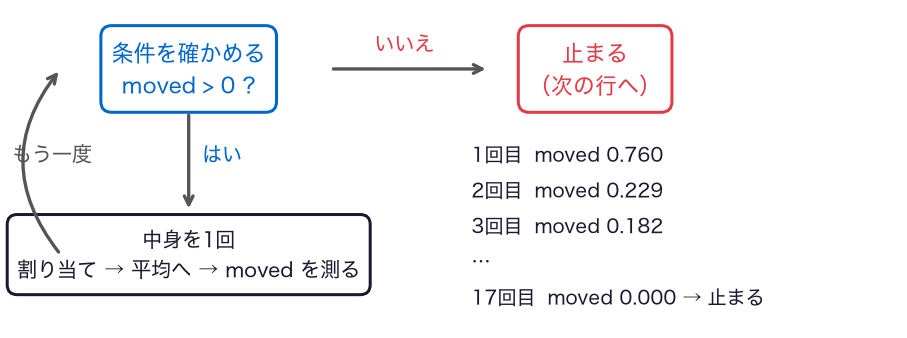

- 毎回、中身の前に条件を確かめる。満たさなくなったら、次の行へ進む

## 重要概念：while

3節 ⑤ くり返す●●●●●●

whileは、条件を満たすあいだ、くり返す。何回で終わるかが先に決まらないくり返しに使う。

## 二乗和は、回るたびに下がる

3節 ⑥ 二乗和●○○

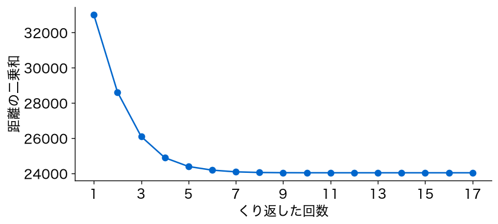

- 中心までの距離の二乗和（群内平方和）は、割り当てでも更新でも、増えない
- だから、いつかは動かなくなって止まる

## お手本：KMeansと比べる

3節 ⑥ 二乗和●●○

```python
km_s = KMeans(2, init=X[[0, 1]], n_init=1, tol=0)
km_s.fit(X)
print(km_s.n_iter_, (km_s.labels_ == lab).all())
```

```
17 True
```

- 同じ出発点から始めると、`KMeans`も同じ回数で止まり、群の番号もすべて同じ

## 1行ずつ：KMeansと比べる

3節 ⑥ 二乗和●●●

```python
km_s = KMeans(2, init=X[[0, 1]], n_init=1, tol=0)
km_s.fit(X)
print(km_s.n_iter_, (km_s.labels_ == lab).all())
```

- 1行目：出発点を0番目と1番目の星にし（`init`）、出発点は1通りだけ（`n_init=1`）、止まる条件はぴったり動かなくなるまで（`tol=0`）
- 2行目：当てはめる
- 3行目：くり返した回数と、群の番号がすべて同じか（`all`）を表示する

## では、見た目どおりの分け方は？

3節 ⑦ 見た目どおり●○○○

- 目安の線の分け方（主系列と白色矮星）から始めたら、k-meansはどう動くか
- 目安の線の群で中心を出し、もう一度割り当ててみる

## お手本：見た目どおりから始める

3節 ⑦ 見た目どおり●●○○

```python
eye = df['白色矮星'].values
C_eye = update(X, eye)
lab_eye = assign(X, C_eye)
print((lab_eye != eye).sum(), '個が群を移る')
```

```
3 個が群を移る
```

## 1行ずつ：見た目どおりから始める

3節 ⑦ 見た目どおり●●●○

```python
eye = df['白色矮星'].values
C_eye = update(X, eye)
lab_eye = assign(X, C_eye)
print((lab_eye != eye).sum(), '個が群を移る')
```

- 1行目：目安の線の0・1を、群の番号として取り出す
- 2・3行目：その群で中心を出し（更新）、もう一度割り当てる
- 4行目：番号が変わった星の数を表示する。3個だけ。ほぼ動かない

## 見た目どおりでも、止まる

3節 ⑦ 見た目どおり●●●●

- 見た目どおりの分け方も、k-meansの手順ではほとんど動かない。そこで止まる
- 止まる先は、出発点しだいで1つではない
- では、`KMeans`は、なぜ輪切りのほうを選んだのか

## お手本：二乗和を比べる

3節 ⑧ 比べる●○○○○

```python
def ss(X, lab):
    C = update(X, lab)
    return round(((X - C[lab]) ** 2).sum())

print(ss(X, eye), ss(X, lab))
```

```
45877 24035
```

## 1行ずつ：二乗和を比べる

3節 ⑧ 比べる●●○○○

```python
def ss(X, lab):
    C = update(X, lab)
    return round(((X - C[lab]) ** 2).sum())

print(ss(X, eye), ss(X, lab))
```

- 2行目：群ごとの中心を出す
- 3行目：`C[lab]`は星ごとの「自分の群の中心」。差を2乗して、全部足す
- 5行目：見た目どおりの分け方と、k-meansの分け方で比べる

## 輪切りのほうが、二乗和が小さい

3節 ⑧ 比べる●●●○○

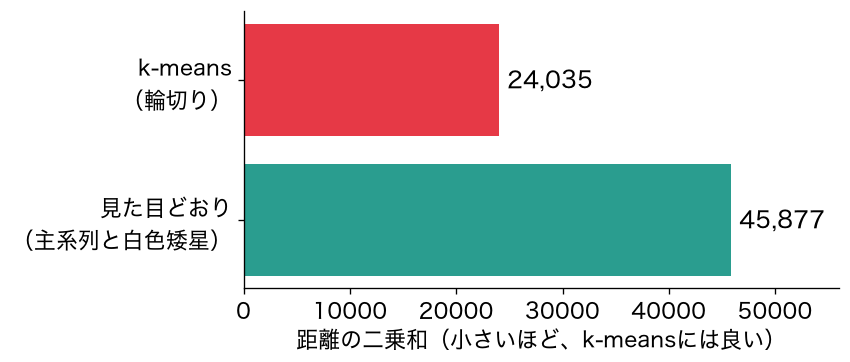

- `n_init=10`は、10通りの出発点から始め、二乗和がいちばん小さい答えを選ぶ

## なぜ輪切りが小さい？

3節 ⑧ 比べる●●●●○

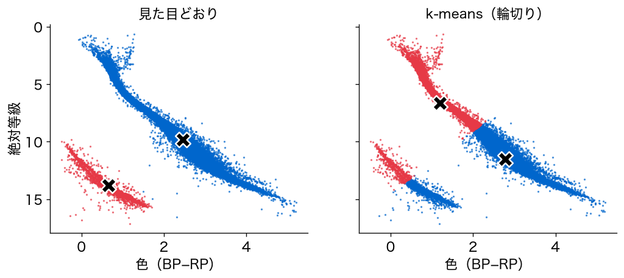

- 主系列は長い。中心を1つにすると、帯の端の星が中心から遠くなる

## 重要概念：丸い群を探す

3節 ⑧ 比べる●●●●●

k-meansは、中心までの距離の二乗和を小さくする分け方を探す。だから丸くまとまった群を好み、細長い群は輪切りにする。

## 止まる所は1つか？

3節 ⑨ 局所解●○○

```
いちばん小さい二乗和 14038  20回のうち届いた回数 2
```

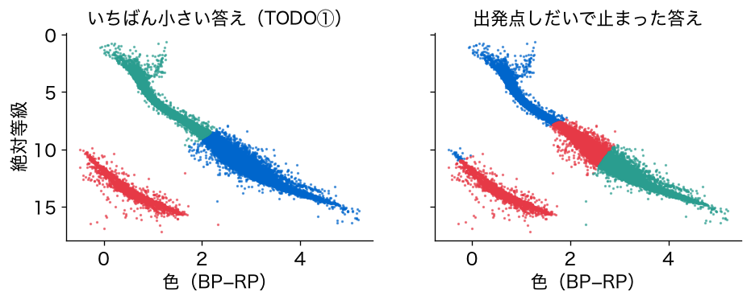

- 3つに分けるとき、出発点をでたらめに20通り替えると、いちばん小さい二乗和に届くのは2回だけ
- 止まった所が、いちばん低いとは限らない。これを局所解という

## だから、何通りも試す

3節 ⑨ 局所解●●○

- 2節からの`n_init=10`は、出発点を10通り試し、二乗和がいちばん小さい答えを残す設定
- TODO①の3つの群も、こうして選ばれていた
- さきほどの「見た目どおりでも止まる」も、同じ局所解の話だった

## 重要：答えは出発点しだい

3節 ⑨ 局所解●●●

k-meansは、止まった所がいちばん良いとは限らない（局所解）。出発点を何通りも試し、二乗和がいちばん小さい答えを選ぶ。

## TODO②：出発点を替える

3節 10 出発点●○

```python
# TODO: [0, 1] を [0, 6] に替えて実行する（6番の星は白色矮星）
C = X[[0, 1]]
moved = 1.0
while moved > 0:
    lab_x = assign(X, C)
    C_new = update(X, lab_x)
    moved = np.abs(C_new - C).max()
    C = C_new
pd.crosstab(df['白色矮星'], lab_x)
```

- 予想：白色矮星の星を出発点にすれば、白色矮星の群ができるか

## ここまでで分かったこと

3節 10 出発点●●

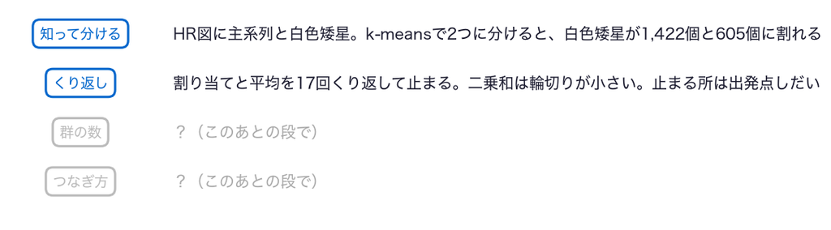

- まだ分からないのは、群の数をいくつにすればよいか

## ノートへ：3節

3節 11 ノートへ●

- 3節のセルを上から実行し、スライドと同じ数が出るか確かめる
- TODO②：予想を書く → `[0, 1]`を`[0, 6]`に替えて実行 → 予想と比べる

動画の人は、ここで一時停止。

## 答え合わせ：TODO②

3節 12 答え合わせ●

```
col_0      0     1
白色矮星
0      18394  7439
1       1428   599
13 回で止まる。二乗和 24035
```

- 白色矮星から始めても、白色矮星の群はできない。止まった先は、ほぼ同じ輪切り（二乗和も同じ）
- 出発点の星が白色矮星でも、1回目の更新で、中心は帯の平均へ引っぱられる

# 4. 何個に分ければよい？

## 段3：群の数を決める

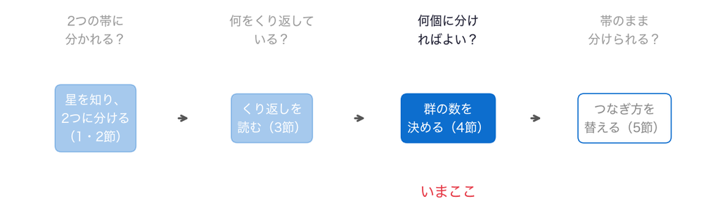

- 問い：群の数は、何個にすればよいか

## 前の段から

- k-meansは、割り当てと更新を、中心が動かなくなるまでくり返す
- 中心までの距離の二乗和を小さくするので、長い主系列は輪切りになる
- ここまで、群の数は2や3と、私が決めて渡してきた

## 群の数は、誰が決める？

4節 ① 群の数●

- k-meansは、群の数を渡さないと動かない
- 答えの列が無いので、正解率のような物差しも使えない
- データから、群の数の目安を出す指針がいくつかある。今日は3つ並べる

## お手本：群の数ごとの二乗和

4節 ② 二乗和の曲線●○○○

```python
ws = []
for k in range(1, 9):
    km_k = KMeans(k, n_init=10, random_state=0)
    km_k.fit(X)
    ws.append(km_k.inertia_)
print(np.round(ws, 1))
```

```
[55720.  24035.6 14037.7  7671.1  5005.1  3716.1  2973.2  2434.9]
```

## 1行ずつ：群の数ごとの二乗和

4節 ② 二乗和の曲線●●○○

```python
ws = []
for k in range(1, 9):
    km_k = KMeans(k, n_init=10, random_state=0)
    km_k.fit(X)
    ws.append(km_k.inertia_)
print(np.round(ws, 1))
```

- 1行目：空のリスト`ws`を用意する（第4回）
- 2〜4行目：群の数`k`を1から8まで替えて、k-meansを当てはめる
- 5行目：二乗和（`inertia_`）をリストの後ろに足す。6行目：8つの二乗和を表示する

## お手本：二乗和を描く

4節 ② 二乗和の曲線●●●○

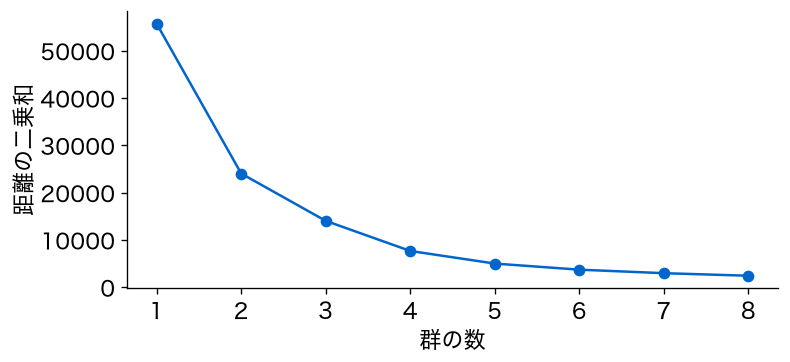

```python
plt.plot(range(1, 9), ws, 'o-')
plt.xlabel('群の数')
plt.ylabel('距離の二乗和')
plt.show()
```

## 二乗和は、増やすほど下がる

4節 ② 二乗和の曲線●●●●

- 群を増やせば、どの星も中心に近くなる。二乗和は必ず下がる
- 下がり方が急にゆるむ点（エルボー）の数を選ぶ考えを、エルボー法という
- この曲線だけでは、エルボーがどこか読みにくい。下がり幅を数で見る

## お手本：下がり幅を見る

4節 ③ エルボー●○○

```python
drops = []
for k in range(1, 8):
    drops.append(round(ws[k - 1] - ws[k]))
print(drops)
```

```
[31684, 9998, 6367, 2666, 1289, 743, 538]
```

## 1行ずつ：下がり幅を見る

4節 ③ エルボー●●○

```python
drops = []
for k in range(1, 8):
    drops.append(round(ws[k - 1] - ws[k]))
print(drops)
```

- 1行目：下がり幅をためる、空のリストを作る
- 2・3行目：群の数を1つ増やしたときに、二乗和がどれだけ下がったか（前の二乗和 − 次の二乗和）をためる。`ws[0]`が群1つ
- 4行目：7つの下がり幅を表示する

## エルボーは2

4節 ③ エルボー●●●

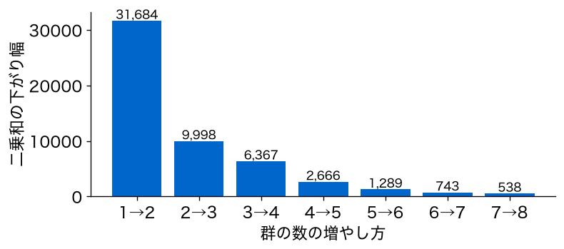

- 1つから2つで31,684下がり、2つから3つでは9,998。そこから下がり方が急にゆるむ。エルボー法なら2つ

## Gap統計の考え

4節 ④ Gap●○○○○○

- 群の無いデータでも、群を増やせば二乗和は下がる
- そこで、群の無い偽のデータを作り、同じようにk-meansをかけて比べる
- 本物の二乗和が、偽より大きく下がった分だけ、本物には群がある

## 偽の星

4節 ④ Gap●●○○○○

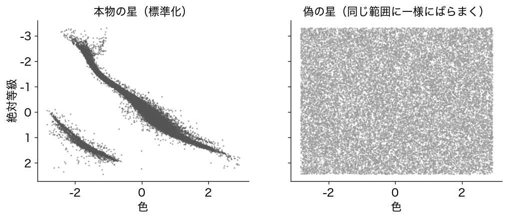

- 本物と同じ範囲に、一様にばらまいた星。帯も塊も無い

## お手本：偽の星を作る

4節 ④ Gap●●●○○○

```python
rng = np.random.default_rng(0)
fake = rng.uniform(X.min(axis=0), X.max(axis=0), size=X.shape)
print(fake[:3].round(2))
```

```
[[ 0.83 -1.76]
 [-2.61 -3.22]
 [ 1.84  1.94]]
```

## 1行ずつ：偽の星を作る

4節 ④ Gap●●●●○○

```python
rng = np.random.default_rng(0)
fake = rng.uniform(X.min(axis=0), X.max(axis=0), size=X.shape)
print(fake[:3].round(2))
```

- 1行目：乱数を作る道具を、シード0で用意する
- 2行目：列ごとの最小から最大までの範囲に、本物と同じ数の星を一様にばらまく
- 3行目：先頭3つの偽の星を見る

## 式：Gap

4節 ④ Gap●●●●●○

群の数 $k$ の本物の二乗和を $W_k$、偽の二乗和を $W_k^{*}$ とする。

$$\mathrm{Gap}(k) = \overline{\log W_k^{*}} - \log W_k$$

- 偽は5組作り、$\log W_k^{*}$ を平均する（上の線）
- Gapが、次の群の数でもう伸びなくなる、いちばん小さい $k$ を選ぶ

## お手本：二乗和の対数を返す関数

4節 ④ Gap●●●●●●

```python
def log_w(Z, k):
    km_z = KMeans(k, n_init=10, random_state=0)
    km_z.fit(Z)
    return np.log(km_z.inertia_)
```

- 本物にも偽にも同じ手順を当てるので、関数にする（第7回）

## お手本：群の数ごとのGap

4節 ⑤ Gapを出す●○○

```python
rng = np.random.default_rng(0)
gaps = []
sds = []
for k in range(1, 9):
    fake_w = []
    for b in range(5):
        fake = rng.uniform(X.min(axis=0), X.max(axis=0), size=X.shape)
        fake_w.append(log_w(fake, k))
    gaps.append(np.mean(fake_w) - log_w(X, k))
    sds.append(np.std(fake_w) * np.sqrt(1 + 1 / 5))
print(np.round(gaps, 3))
```

```
[1.016 1.387 1.468 1.617 1.872 2.006 2.06  2.095]
```

## 1行ずつ：群の数ごとのGap①

4節 ⑤ Gapを出す●●○

```python
rng = np.random.default_rng(0)
gaps = []
sds = []
for k in range(1, 9):
    fake_w = []
    for b in range(5):
        fake = rng.uniform(X.min(axis=0), X.max(axis=0), size=X.shape)
        fake_w.append(log_w(fake, k))
    gaps.append(np.mean(fake_w) - log_w(X, k))
    sds.append(np.std(fake_w) * np.sqrt(1 + 1 / 5))
print(np.round(gaps, 3))
```

- 1〜3行目：乱数の道具をシード0で用意し直し、空のリスト`gaps`と`sds`を作る
- 4行目：群の数`k`を1から8まで替える
- 5行目：その`k`での、偽の二乗和の対数をためるリストを作る

## 1行ずつ：群の数ごとのGap②

4節 ⑤ Gapを出す●●●

```python
rng = np.random.default_rng(0)
gaps = []
sds = []
for k in range(1, 9):
    fake_w = []
    for b in range(5):
        fake = rng.uniform(X.min(axis=0), X.max(axis=0), size=X.shape)
        fake_w.append(log_w(fake, k))
    gaps.append(np.mean(fake_w) - log_w(X, k))
    sds.append(np.std(fake_w) * np.sqrt(1 + 1 / 5))
print(np.round(gaps, 3))
```

- 6〜8行目：偽の星を5組作り、それぞれの二乗和の対数をためる
- 9行目：偽の平均から本物を引いたGapを、`gaps`に足す
- 10・11行目：偽の5組の揺れ`s`を`sds`にためる（あとで使う）。8つのGapを表示する

## えっ、Gapは止まらない

4節 ⑥ Gapを読む●○

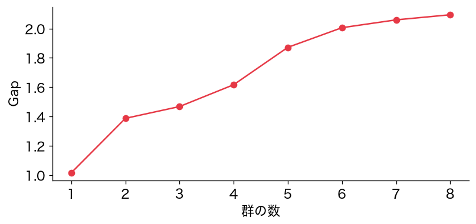

- Gapは、群を増やすたびに伸び続ける。8までに、伸びが止まる数が無い

## 輪切りは、いくらでも得をする

4節 ⑥ Gapを読む●●

- 長い主系列は、細かく切るほど、本物の二乗和が大きく下がる
- 偽の星には帯が無いので、そこまでは下がらない
- Gapも、k-meansと同じ「中心までの距離」の物差しで測っている

## Gapの規則：揺れを入れる

4節 ⑦ Gapの規則●○○○

偽の星は乱数で作るので、Gapにも揺れがある。偽の5組の $\log W_k^{*}$ の標準偏差を使って、揺れ $s_k$ を決める。

$$\text{選ぶのは、} \ \mathrm{Gap}(k) \ge \mathrm{Gap}(k+1) - s_{k+1} \ \text{を満たす、いちばん小さい } k$$

- 次の数で伸びても、その伸びが揺れより小さければ、伸びていないとみなす

## お手本：規則で選ぶ

4節 ⑦ Gapの規則●●○○

```python
for k in range(1, 8):
    print(k, gaps[k - 1] >= gaps[k] - sds[k])
```

```
1 False
2 False
3 False
4 False
5 False
6 False
7 False
```

## 1行ずつ：規則で選ぶ

4節 ⑦ Gapの規則●●●○

```python
for k in range(1, 8):
    print(k, gaps[k - 1] >= gaps[k] - sds[k])
```

- 1行目：群の数`k`を1から7まで替える
- 2行目：`gaps[k - 1]`が群`k`のGap、`gaps[k]`と`sds[k]`が群`k + 1`のGapと揺れ。規則を満たせばTrue

## 規則でも、選ばれない

4節 ⑦ Gapの規則●●●●

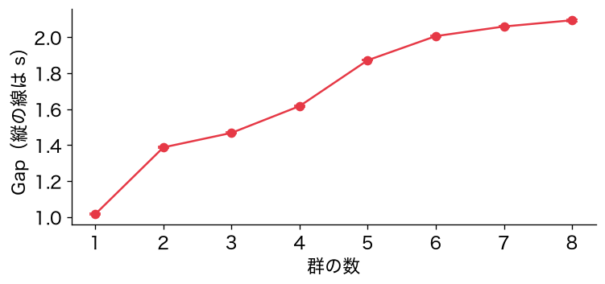

- 揺れ（縦の線）は、ごく小さい。どの数でも、次の数のGapのほうがはっきり大きい
- 規則を満たす数は、1〜7のどこにも無い。Gapは群の数を選ばない

## シルエットの考え

4節 ⑧ シルエット●○○○○○

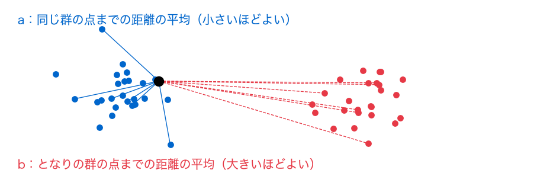

- 星ごとに、自分の群の中の近さ $a$ と、となりの群までの近さ $b$ を比べる

## 式：シルエット

4節 ⑧ シルエット●●○○○○

$$s_i = \frac{b_i - a_i}{\max(a_i, b_i)}$$

- 自分の群の中で近く、となりの群から遠いほど、1に近い
- 全部の星の $s_i$ を平均し、いちばん大きい群の数を選ぶ

## お手本：シルエット

4節 ⑧ シルエット●●●○○○

```python
from sklearn.metrics import silhouette_score
sils = []
for k in range(2, 9):
    lab_k = KMeans(k, n_init=10, random_state=0).fit_predict(X)
    sils.append(silhouette_score(X, lab_k, sample_size=5000,
                                 random_state=0))
print(np.round(sils, 3))
```

```
[0.571 0.636 0.536 0.528 0.505 0.497 0.488]
```

## 1行ずつ：シルエット

4節 ⑧ シルエット●●●●○○

```python
from sklearn.metrics import silhouette_score
sils = []
for k in range(2, 9):
    lab_k = KMeans(k, n_init=10, random_state=0).fit_predict(X)
    sils.append(silhouette_score(X, lab_k, sample_size=5000,
                                 random_state=0))
print(np.round(sils, 3))
```

- 3・4行目：群の数を2から8まで替え、当てはめて群の番号を出す（`fit_predict`）
- 5・6行目：シルエットを出してためる。計算が重いので、5,000個を抜き出して測る
- 7行目：7つのシルエットを表示する

## シルエットは3がいちばん

4節 ⑧ シルエット●●●●●○

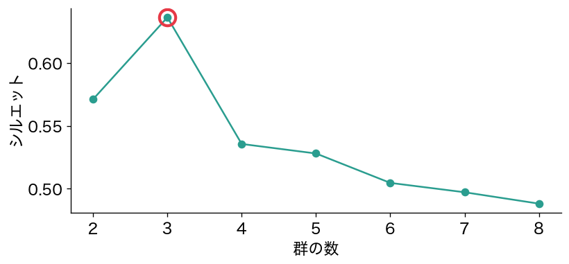

- 3つに分けたときが、いちばん大きい